# Lecture 3: MT4113

Eric Rexstad  
27 Sept 2017

### Announcements

- Assignment 1 due **1200** Monday 02Oct via MMS
  - single file upload as a plain text file (can be `source()` in R)
- Assignment 1 will be peer-reviewed
  - you will receive access to submissions of two anonymous colleagues
  - you will provide *useful* comments embedded in their code
  - upload to MMS, I will see comments are returned to author of the code
- Office hour/drop-in session
  - Wednesday afternoons 1300

### Comparative advantages of creating functions

- construction
  - function does only one thing
- testing
  - function does only one thing
- debugging
  - function does only one thing
- maintenance
  - less duplication, modifications easy to make
- expansion/enhancement
  - improving a function makes improvement available to all code using the function
- re-use
  - general functions can built into warehouse of tools
- *disadvantage*
  - more planning required before coding
  - slight execution time cost

### Concepts of functional programming

- **encapsulation**
  - send everything needed for computation into function as arguments
  - return outputs explicitly with `return()` function
  - do not make changes to objects outside the function (**principle of least privilege**)
    - very rarely might it be useful violate this principle
    - these are types of exceptions that need documentation in code

### Example: principle of least privilege

Variables within a function at time of definition

- populated with *different* values at time of execution

```r
print.and.multiply <- function(x, y) {
   print(paste('Starting function x=', x, 'y=', y))
   x <- x*y
   print(paste('Before leaving function x=', x))
   return(x)
}
first <- 10
second <- 20
new.object <- print.and.multiply(first, second)
```

```
[1] "Starting function x= 10 y= 20"
[1] "Before leaving function x= 200"
```

```r
first
```

```
[1] 10
```

### Environments

Structures that organise objects in an R programme

- associates a set of names to a set of values

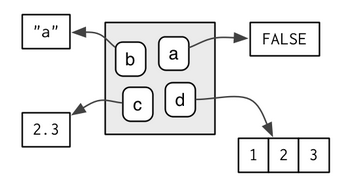

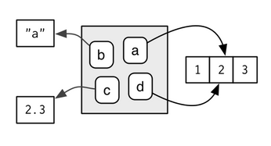

perhaps pointing to same object address

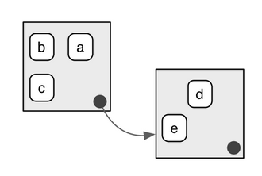

Environments also have parents

For our purposes, we care most about:

- **global environment**
  - this is where your programme does most of its work
- **current environment**
  - comes into existence when inside functions
- when packages are loaded
  - parents of the global environment are added
- viewed using `search()` or the `Environment` tab of R-Studio

```
 [1] ".GlobalEnv"        "package:knitr"     "package:stats"
 [4] "package:graphics"  "package:grDevices" "package:utils"
 [7] "package:datasets"  "package:methods"   "Autoloads"
[10] "package:base"
```

See Wickham (2015) [Section 8](http://adv-r.had.co.nz/Environments.html)

### Scoping

Rules governing how R discovers the value of a symbol (see Wickham 2015 scoping)

- (such as `my.value <- 24`)
- Rule 1: *Name masking*
  - if a name isn't defined in an environment, R looks up one level in the environment structure

> Horrible code you would never write (but you might inherit)

```r
x <- 1
h <- function() {
  y <- 2
  i <- function() {
    z <- 3
    return(c(x, y, z))
  }
  return(i())
}
print(h())
```

```
[1] 1 2 3
```

- An example of functions defined inside other functions
- Calling function `h()` causes `h` to be executed, but also causes `i` to be defined
- After `i` is defined, it is then called via `i()`
- Unpleasantly, neither of the functions `h()` or `i()` have defined arguments
  - yet values of `x`, `y`, and `z` are determined and printed to the console
- Where are these values determined?

### Scoping Rule 2

*Equivalence of search for functions and variables*

Finding functions works the same as finding variables

```r
n <- function(x) x/2
o <- function() {
  n <- 10
  result <- n(n)
  return(result)
}
o()
```

```
[1] 5
```

> It is poor form to give variables and functions the same name; you would never do that

### Scoping Rule 3

*Fresh start*

- each use of a function is independent of any previous uses
- a function's environment is wiped clean for each new use

```r
j <- function() {
  if(!exists("a")) {
    a <- 1
  } else {
    a <- a + 1
  }
  print(a)
}
j()
```

```
[1] 1
```

```r
j()
```

```
[1] 1
```

### Scoping Rule 4

Scoping rules define where to look for values associated with objects

- lookup happens at time code is executed (*dynamic lookup*), not when code (or function) is created

```r
f <- function() x+1
x <- 15
f()
```

```
[1] 16
```

```r
x <- 20
f()
```

```
[1] 21
```

> This is not clever programming, violating the principle of encapsulation

If you have written a lengthy function - and cannot recognise whether it violates the principle of encapsulation - this function is diagnostic

```r
codetools::findGlobals(f)
```

```
[1] "+" "x"
```

### Purpose of learning about scoping and environments

- Proficient programming
  - a good woodworker knows their tools
- understanding scoping can help you diagnose strange behaviour of your code

```r
multiply <- function (x,y) {
   result <- x1*y
   return(result)
 }
x1 <- 10
#
#  more code happened here
#
a <- 7
b <- 20
(multiply.results <- multiply(a,b))
```

```
[1] 200
```

### Testing and debugging

- Why test code?
  - Nobody writes perfect code
  - Testing can demonstrate sections of code work properly
    - reduces *possible suspects* for further debugging
- *Test driven development* (see later)
  - Tests can be used to structure writing of code
- With luxury of a software team
  - Have different people perform testing than those who wrote code
- Debugging methods
  - Compile (interpreter) time
    - Only errors found here are syntax problems or
      - for some languages, whether variables have been initialised for use
  - Batch debugging
    - Peppering code with `print()` statements
    - Run code, examine output to find unexpected (erroneous) results
    - Clumsy approach (code needs to be sanitized of `print()` after errors found)
  - Interactive debugging
    - Set breakpoints
    - Step through code
    - Examine and alter variables while code pauses

### The life of software

Given you are developing software for others to use,

Statistical software, like other goods, have a lifetime with stages

- specification (what should it do)
- definition (how it should be done)
- implementation (writing code)
- verification (checking it meets the specification)
- delivery and usage
- maintenance (keeping it operational)
- Software development is **big business**
- Stands to reason there are systematic approaches to the undertaking
- Software engineers devote their profession to the pursuit
- On this campus, you could take an entire module to the subject
  - CS3051 Software engineering
    - Somerville, I. 2011. Software engineering, 9th Edition. Pearson education

### Two contrasting approaches

- Plan-driven software development
- Agile software development
- Plan-driven (*waterfall* model)
  - specification/definition/implementation done in unwavering order
  - Agreement between user and programmers from the beginning
  - Documentation and verification of each stage of the process
  - Advantage
    - End result is agreed at project beginning
    - Lots of documentation
    - Works well for large projects and large organisations
  - Disadvantages
    - Inflexible, struggles when project requirements change
  - Example
    - “We need software to automate statistical analyses we have previously performed ad-hoc.”
- Agile development (*iterative* model)
  - Planning of project is incremental
  - Do a bit of specification, bit of coding, bit of verification – where do we stand
  - Start simple, modify design, enhance capabilities, repeat
  - Advantage
    - Can respond to changing circumstances
    - Less time agreeing and documenting decisions (more efficient)
  - Disadvantages
    - End-result of code is undefined until the end
    - Less documentation of decisions (less robust than plan-driven)
  - Example
    - “Let's develop a new algorithm and software for predicting consumer spending patterns.”

### Cartoon

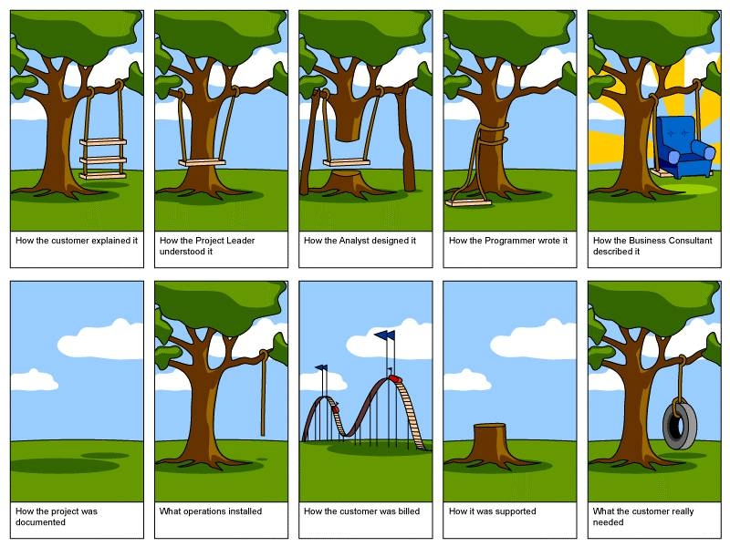

### Software design for statisticians

- Commonly a blend of plan-driven and iterative methods
  - The larger the project (complexity or personnel) the more advantages of plan-driven
  - Time spent in design and documentation are seldom wasted
- Make use of pseudo-code or flowcharts
  - Transition stage between algorithm and code
  - Focus is upon flow of control and approach, rather than syntax
  - Break task into sub-tasks
    - Make modules out of sub-tasks
    - Name modules (verbs) and define inputs/outputs
  - Skeleton of code can now be built with module (function) input/output
    - Each module can have the rudiments of documentation constructed

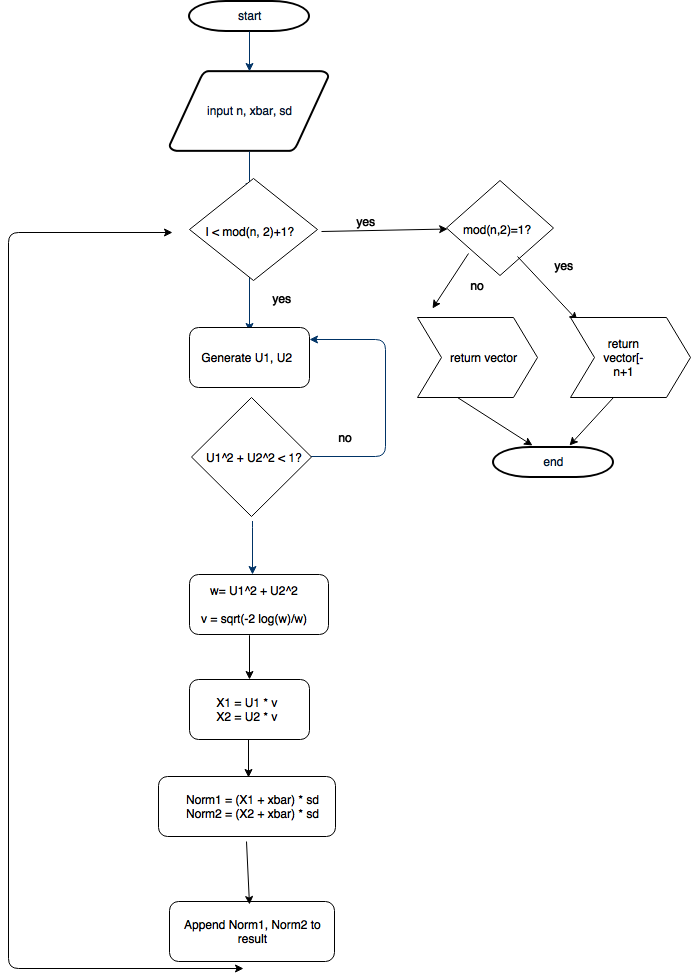

- Finally write the actual code

### Adapting (recycling) existing code

- Don't reinvent the wheel
- **R** being open-source, has lots of code that can be adapted
- If you use code written by someone else
  - Acknowledge them in your use of code (and subsequent reports)
  - Test that it actually performs for your purposes
  - Take time to understand code and learn from it
  - R code in packages might not be examples of good practice, nor easy to comprehend

### Programming style

- Implement principle of least privilege (even though R doesn't mandate this)

  > “Premature optimisation is the source of programming evil” (Knuth or Hoare)
- working code is preferable to fast, broken code
- Seek out redundant code and convert to modules

```r
for (i in 1:num.patients) {
  if(Smoke[i]==0) {
    print(paste("Subject ",i," a Non-smoker has Heartrate", Heartrate[i]))
  } else {
    print(paste("Subject ",i," a Smoker has Heartrate", Heartrate[i]))
  }
}
```

can be re-written as

```r
smoker.status.as.text<-function(status.as.int){
#    Purpose: Returns "Non-smoker" or "Smoker" depending on input status
  return(ifelse(status.as.int==0,"Non-smoker","Smoker"))
}
for (i in 1:num.patients) {
  print(paste("Subject ",i," a ",smoker.status.as.text(Smoke[i])," has Heartrate",Heartrate[i]))
}
```

### Coding practice within modules

- Initialise object used in module at beginning (some languages (C++) require this)
- Include error checks
  - Check that arriving arguments are acceptable at function outset
- Resist temptation to make code terribly dense, for example

```r
if ((((x<6)&(x>7))|((y<0)&(y>1)))&(theta>=0)&(theta<2*pi)) {
```

- Do not nest conditional or looping structures beyond ~3 levels deep

### Coding conventions

- Rules for writing consistent, understandable code
- Rationale
  - Decrease coding errors, increase readability, enhance possible reuse
- Google Inc. has a set of conventions for programmers working for them
  - https://google.github.io/styleguide/Rguide.xml
- All functions begin with comments providing
  - Purpose, input/output, implementation details
- Other comments – make sure they remain current
- Use indentation for control structures (R-Studio helps you with this)
- Meaningful variable names
- Convention for variable and function names
- Combination of upper/lower case and dots
  - Other languages have formal conventions for variables
    - e.g. ALL_UPCASE for constants, prefixes for variable types: (int, real, strng)
- Consistency with spacing around operators `x <- y + 2` or `x<-y+2` not `x<- y+ 2`